# Building modules

## How to write a process module

The aim of a process module is to modify the occurrence data or/and the covariate data prior to modelling. Examples include adding background points, or adding folds for cross-validation.

A process module returns data in exactly the same format that it receives it, taking and returning a `list` of two elements. The first element is a `data.frame` with the columns `'longitude'`, `'latitude'`, `'value'`, `'type'`, `'fold'`, and additional covariate columns (see Occurrence module output). The covariate columns are added internally in the zoon workflow by combining the output of the covariate module. The `data.frame` has an attribute `covCols` which details which columns these are. The second element of the list is a `RasterBrick`, `RasterLayer`, or `RasterStack` object as returned by a covariate module.

In this example we are going to create a process module that cuts down our occurrence data to a user supplied extent.

When writing a module it is useful to have example input to test with. One way to do this is to run a similar `workflow` and use the outputs of that `workflow` to test yours. Here is an example:

```r
# We run a very simple workflow so that we can get example input
# for our module

work5 <- workflow(occurrence = UKAnophelesPlumbeus,
                  covariate  = UKAir,
                  process    = OneHundredBackground,
                  model      = LogisticRegression,
                  output     = PrintMap)
```

```
## Occurrence data does not have a "crs" column, zoon will assume it is in the same projection as the covariate data
```

```
## There are fewer than 100 cells in the environmental raster.
## Using all available cells (81) instead
```

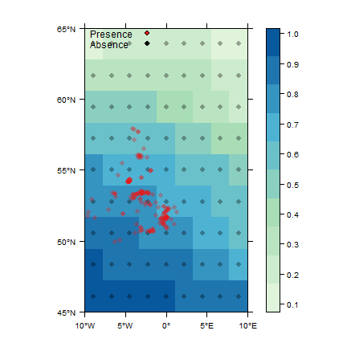

```r
# The output from a process module is in the same format as the
# input, so we can use the output of OneHundredBackground as the testing
# input for our module. Note that this object should be called .data

.data <- Process(work5)

str(.data, 2)
```

```
## List of 2
##  $ df :'data.frame': 269 obs. of  6 variables:
##   ..$ value    : num [1:269] 1 1 1 1 1 1 1 1 1 1 ...
##   ..$ type     : Factor w/ 2 levels "background","presence": 2 2 2 2 2 2 2 2 2 2 ...
##   ..$ fold     : num [1:269] 1 1 1 1 1 1 1 1 1 1 ...
##   ..$ longitude: num [1:269] 1.01 -0.16 -2.83 -0.63 -3.53 ...
##   ..$ latitude : num [1:269] 52.4 51.6 53.4 51.6 56 ...
##   ..$ layer    : num [1:269] 271 272 272 272 271 ...
##   ..- attr(*, "call_path")=List of 1
##   ..- attr(*, "covCols")= chr "layer"
##  $ ras:Formal class 'RasterLayer' [package "raster"] with 12 slots
##  - attr(*, "call_path")=List of 3
##   ..$ occurrence: chr "UKAnophelesPlumbeus"
##   ..$ covariate : chr "UKAir"
##   ..$ process   : chr "OneHundredBackground"
```

It is important to note that the `list` object that is passed into a process module is named `.data`, and so when writing our module we need to adhere to this convention.

First, lets have a look at the input:

```r
# The first element is the occurrence data

head(.data$df)
```

```
##   value     type fold   longitude latitude    layer
## 1     1 presence    1  1.01287600 52.37696 271.4658
## 2     1 presence    1 -0.16003467 51.57146 272.2655
## 3     1 presence    1 -2.83497900 53.40813 271.6481
## 4     1 presence    1 -0.62955210 51.55540 272.2655
## 5     1 presence    1 -3.52534680 56.04848 271.2964
## 6     1 presence    1  0.01144066 51.58168 272.2655
```

```r
# The attribute covCols gives the covariate columns

attr(.data$df, 'covCols')
```

```
## [1] "layer"
```

```r
# If we want to modify these covariate columns in
# our process module we can select them using this
# attribute

head(.data$df[attr(.data$df, 'covCols')])
```

```
##      layer
## 1 271.4658
## 2 272.2655
## 3 271.6481
## 4 272.2655
## 5 271.2964
## 6 272.2655
```

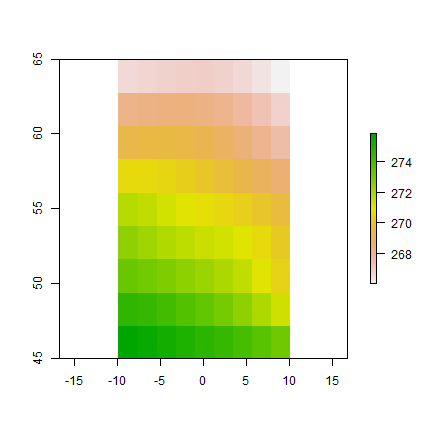

```r
# The second element is the raster

plot(.data$ras)
```

Let’s start writing our new process module.

```r
# Start writing our module

ClipOccurence <- function(.data,
                          extent = c(-180, 180, -180, 180)){
```

Here we have remembered to give `.data` as an argument as this is a default for process modules. In addition we have supplied an argument for the extent and set the default to the entire globe (i.e. no clipping). It is important that all of your arguments have defaults (even if the default might not be a good idea in practice), as this allows the zoon system to perform automatic testing on your modules when you share them online.

```r
# Write the body of our function
# extract the occurrence data from the .data object

occDF <- .data$df

# Subset by longitude

occSub <- occDF[occDF$longitude >= extent[1] &
                occDF$longitude <= extent[2], ]

# Subset by latitude

occSub <- occSub[occSub$latitude >= extent[3] &
                 occSub$latitude <= extent[4], ]

# assign this data.frame back to the .data object

.data$df <- occSub
```

So our simple process function looks like this:

```r
ClipOccurrence <- function(.data, extent = c(-180, 180, -180, 180)){

  # Write the body of our function
  # extract the occurrence data from the .data object

  occDF <- .data$df

  occSub <- occDF[occDF$longitude >= extent[1] &
                  occDF$longitude <= extent[2], ]

  occSub <- occSub[occSub$latitude >= extent[3] &
                   occSub$latitude <= extent[4], ]

  .data$df <- occSub

  return(.data)

}
```

Our next step is to test that this function will work in a `workflow`. Once we have read in our function so that it is available in our working environment we can then include it in a `workflow` as we would a normal module.

```r
# Run a workflow with our new process

# In this example we first add background points, then clip the data

work6 <- workflow(occurrence = UKAnophelesPlumbeus,
                  covariate  = UKAir,
                  process    = Chain(OneHundredBackground,
                                     ClipOccurrence(extent = c(-3, 2, 50, 53))),
                  model      = LogisticRegression,
                  output     = PrintMap)
```

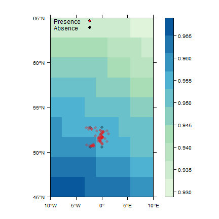

We can see that the data has been clipped to the extent we specified in the map printed by the output module.

The next stage is to turn this function into a module which is shareable. To do this we need to add metadata to our function using the `BuildModule()` function. Once `BuildModule()` has created your module it will run it through checks to make sure has the required features, outputs data in the correct format, etc. Checking can be turned off by setting the argument `check = FALSE`.

```r
# Build our module

BuildModule(ClipOccurrence,
            type = 'process',
            title = 'Clip occurrence data to extent',
            description = paste('This process module clips the occurrence',
                                'data that is returned from the occurrence',
                                'module to a user defined extent'),
            details = paste('The extent is a square region which denotes the',
                            'area within which observations will be kept.',
                            'All data that falls outside of the extent will',
                            'be removed and will be not be used in the',
                            'modelling process'),
            version = 0.1,
            author = 'Z.O. Onn',
            email = 'zoon@zoon-zoon.com',
            paras = list(extent = paste('A numeric vector of length for',
                                        'giving (in this order) the minimum',
                                        'longitude, maximum longitude, minimum',
                                        'latitude, maximum latitude.')),
            dataType = c('presence-only', 'presence/absence',
                         'presence/background', 'abundance',
                         'proportion'))
```

```
## Starting checks...
```

```
## done
```

```
## [1] "ClipOccurrence"
```

Much of how to use `BuildModule()` is self-explanatory but two parameters are worth mentioning here. The `paras` argument takes a named `list` of the parameters the module takes. This should follow the following structure; *list(parameterName = ‘Parameter description.’, anotherParameter = ‘Another description.’)*, but should not include the defaults (i.e. we do not include `.data`). `dataType` describes the types of occurrence data that this module will work with. Certain modules might only work with presence-only data for example. In our case, our module will work with any type of data and so we list all the data types in the `dataType` field.

Once `BuildModule()` has been run there will be an `R` file in our working directory that represents our module and can be shared with others. This `R` script can be used as follows:

```r
# remove the original function from our environment

rm(list = 'ClipOccurrence')

# Load the module script

LoadModule('ClipOccurrence.R')
```

```
## [1] "ClipOccurrence"
```

```r
work7 <- workflow(occurrence = AnophelesPlumbeus,
                  covariate = UKBioclim,
                  process = Chain(OneHundredBackground,
                                  ClipOccurrence(extent = c(-5, 5, 50, 55))),
                  model = LogisticRegression,
                  output = PrintMap)
```

```
## 152 records found
```

```
## 0-
```

```
## 152 records downloaded
```

```
## Occurrence data does not have a "crs" column, zoon will assume it is in the same projection as the covariate data
```

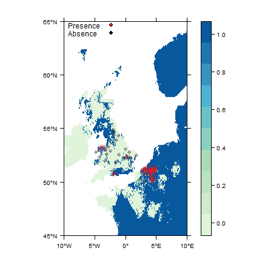

Once we’re happy with the module, we will hopefully upload it to the zoon repository. The repository is currently under development. Visit [the development pages](https://zoonproject.wordpress.com/) for more information.

## How to write a model module

Here is a simple function that will become our module. It is a model module that uses generalised additive models. We will work through it one element at a time

First we start our function by declaring all the parameters we need, including all the defaults

```r
GamGam <- function(.df){
```

Since this is a model module the only default is `.df`. To find out more about defaults see the section Module IO definitions for module developers. `.df` is a `data.frame` with columns: `'longitude'`, `'latitude'`, `'value'`, `'type'`, `'fold'`, and additional covariate columns (see Occurrence module output). The names of the covariate columns are given as an attribute of the table: `attr(.df, 'covCols')]`.

Next we specify the packages our function needs. These should be specified by using `GetPackage()` function in the zoon package. This function will load the package if the user of your module already has it or will install it from CRAN if they don’t. For this reason make sure your package only uses packages that are on CRAN.

```r
# Specify the packages we need using the function
# GetPackage

zoon::GetPackage("gam")
```

Next we can add the code that does our modelling, here we create a simple GAM (Generalised Additive Model) using the package gam

```r
# Create a data.frame of covariate data

covs <- .df[colnames(.df) %in% attr(.df, 'covCols')]

# do a bit of copy-pasting to define smooth terms for each covariate

f <- sprintf('.df$value ~ s(%s)',
             paste(colnames(covs),
             collapse = ') + s('))

# Run our gam model

m <- gam::gam(formula = formula(f),
              data = covs,
              family = binomial)
```

The final stage of building a model module is to write some code within the function to create a `ZoonModel` object. This is important as it standardises all outputs from model modules and crucially enables zoon to make predictions from them in a predictable and standard way.

We build a `ZoonModel` object by using the function `ZoonModel()`. This takes three parameters:

- **`model`**: Your model object
- **`code`**: A section of code that will use `model` [your model] and **`newdata`** [a new set of covariate data], to return a vector of predicted values, one for each row of `newdata`
- **`packages`**: A vector of characters naming the packages needed to run `code`

```r
# Create a ZoonModel object to return.
# this includes our model, predict method
# and the packages we need.

ZoonModel(model = m,
          code = {

          # create empty vector of predictions

          p <- rep(NA, nrow(newdata))

          # omit NAs in new data

          newdata_clean <- na.omit(newdata)

          # get NA indices

          na_idx <- attr(newdata_clean, 'na.action')

          # if there are no NAs then the index should
          # include all rows, else it should name the
          # rows to ignore

          if (is.null(na_idx)){
            idx <- 1:nrow(newdata)
          } else {
            idx <- -na_idx
          }

          # Use the predict function in gam to predict
          # our new values

          p[idx] <- gam::predict.gam(model,
                                     newdata_clean,
                                     type = 'response')
          return (p)
        },
        packages = 'gam')
```

With all these elements in place we now have our module complete. All together it looks like this:

```r
GamGam <- function(.df){

  # Specify the packages we need using the function
  # GetPackage

  zoon::GetPackage("gam")

  # Create a data.frame of covariate data

  covs <- .df[colnames(.df) %in% attr(.df, 'covCols')]

  # do a bit of copy-pasting to define smooth terms for each covariate

  f <- sprintf('.df$value ~ s(%s)',
               paste(colnames(covs),
                     collapse = ') + s('))

  # Run our gam model

  m <- gam::gam(formula = formula(f),
                data = covs,
                family = binomial)

  # Create a ZoonModel object to return.
  # this includes our model, predict method
  # and the packages we need.

  ZoonModel(model = m,
            code = {

            # create empty vector of predictions

            p <- rep(NA, nrow(newdata))

            # omit NAs in new data

            newdata_clean <- na.omit(newdata)

            # get their indices

            na_idx <- attr(newdata_clean, 'na.action')

            # if there are no NAs then the index should
            # include all rows, else it should name the
            # rows to ignore

            if (is.null(na_idx)){
              idx <- 1:nrow(newdata)
            } else {
              idx <- -na_idx
            }

            # Use the predict function in gam to predict
            # our new values

            p[idx] <- gam::predict.gam(model,
                                       newdata_clean,
                                       type = 'response')
            return (p)
          },
          packages = 'gam')

}
```

We then run `BuildModule()` on our function, adding the required metadata. As this module has no parameters other than `.df` which is not user specified, we don’t need to set the `paras` argument, which would normally be used to document arguments. Default arguments, like `.df` are all signified by starting with a `.` and don’t need to be documented as this will be written into the module documentation automatically. It is worth noting the `dataType` field. This must be any of `'presence-only'`, `'presence/absence'`, `'presence/background'`, `'abundance'` or `'proportion'`. This is important so that people using your module in the future will know what types of data can be used as inputs. Once `BuildModule()` has created your module it will run it through checks to make sure has the required features, outputs data in the correct format, etc. Checking can be turned off by setting the argument `check = FALSE`.

```r
BuildModule(object = GamGam,
            type = 'model',
            title = 'GAM sdm model',
            description = 'This is my mega cool new model.',
            details = paste('This module performs GAMs (Generalised Additive',
                            'Models) using the gam function from the package gam.'),
            version = 0.1,
            author = 'Z. Oon',
            email = 'zoon@zoon.com',
            dataType = c('presence-only', 'presence/absence'))
```

```
## Starting checks...
```

```
## done
```

```
## [1] "GamGam"
```

This is now a runable module.

```r
# remove the function in our workspace else
# this will cause problems

rm(GamGam)

# Load in the module we just built

LoadModule('GamGam.R')
```

```
## [1] "GamGam"
```

```r
# Run a workflow using our module

work8 <- workflow(occurrence = UKAnophelesPlumbeus,
                  covariate = UKAir,
                  process  = OneHundredBackground,
                  model = GamGam,
                  output = PrintMap)
```

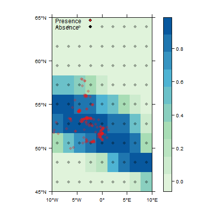

Once we’re happy with the module, we will hopefully upload it to the zoon repository. The repository is currently under development. Visit [the development pages](https://zoonproject.wordpress.com/) for more information.

## How to write an output module

An output module is the last module in a zoon `workflow` and is an opportunity to summarise the model results, make predictions, or otherwise visualise the data or results. The input to output modules is a combination of the outputs of occurrence, process and model modules providing many possible output types. The specific inputs are `.model`, a list with the two named elements `model` (a `ZoonModel` object) and `data` (`data.frame` with the columns: `'longitude'`, `'latitude'`, `'value'`, `'type'`, `'fold'`, `'predictions'`, plus additional named columns giving associated covariate values), and `.ras`, a `RasterLayer`, `RasterBrick` or `RasterStack` object. Depending on your desired output you may not utilise some of these inputs.

In this example we will create an output module that uses the model output to predict the species occurrence in a new location given by a user-provided raster.

When writing a module it is useful to have example input to test with. One way to do this is to run a similar `workflow` and use the outputs of that `workflow` to test yours. Here is an example:

```r
# We run a very simple workflow so that we can get example input
# for our module

work9 <- workflow(occurrence = UKAnophelesPlumbeus,
                  covariate  = UKAir,
                  process    = OneHundredBackground,
                  model      = LogisticRegression,
                  output     = PrintMap)

# The input to an output module is a combination of the output
# from the model module and the covariate module. We can recreate
# it for this work flow like this

.model <- Model(work9)
.ras <- Covariate(work9)
```

Both `.model` and `.ras` are default arguments for an output model so it is important that you have them as arguements for your module, even if you dont use them both. It is also important that you stick to the same naming conventions.

```r
# Our output module takes the default parameters and a user-defined
# Raster* object that has the same structure as the raster layer output
# by the covariate module

PredictNewRasterMap <- function(.model, .ras, raster = .ras){
```

It is important to have default values for all user defined parameters so that your module can be tested when you upload it to the zoon website. Here we set our default ‘new area’ raster to be the same as the raster used to create the model. Clearly this is not how we envisage the module being used in a real application (unless they genuinely wanted to predict back to the same area), however this ensures that this module will always work with its default arguments, no matter what `workflow` it is placed in.

```r
# The first step is to load in the packages we need

zoon::GetPackage("raster")

# Then extract the covariate values
# from the user provided raster

vals <- data.frame(getValues(raster))
colnames(vals) <- names(raster)
```

Once we have these new values we can predict using the `ZoonPredict()` function. This function is very useful as it simplifies the process of making predictions from the ouput of a model module. See the [InteractiveMap](https://github.com/zoonproject/modules/blob/master/R/InteractiveMap.R) module for an innovative visualisation using predicted values.

```r
# Make predictions to the new values

pred <- ZoonPredict(.model$model,
                    newdata = vals)

# Create a copy of the users' raster...
# (just a single layer)

pred_ras <- raster[[1]]

# ... and assign the predicted values to it

pred_ras <- setValues(pred_ras, pred)
```

Once we have the raster of predicted values we can plot it and return the results to the user.

```r
# Plot the predictions as a map

plot(pred_ras)

# Return the raster of predictions

return (pred_ras)
```

Our function now looks like this:

```r
PredictNewRasterMap <- function(.model, .ras, raster = .ras){

  zoon::GetPackage("raster")

  # Extract the values from the user provided raster

  vals <- data.frame(getValues(raster))
  colnames(vals) <- names(raster)

  # Make predictions to the new values

  pred <- ZoonPredict(.model$model,
                      newdata = vals)

  pred_ras <- raster[[1]]
  pred_ras <- setValues(pred_ras, pred)

  # Print the predictions as a map

  plot(pred_ras)

  return(pred_ras)
}
```

Our next step is to test that this function will work in a `workflow`. Once we have read in our function so that it is available in our working environment we can then include it in a `workflow` as we would a normal module.

```r
# Run it with the defaults

work10 <- workflow(occurrence = UKAnophelesPlumbeus,
                   covariate  = UKBioclim,
                   process    = OneHundredBackground,
                   model      = LogisticRegression,
                   output     = PredictNewRasterMap)
```

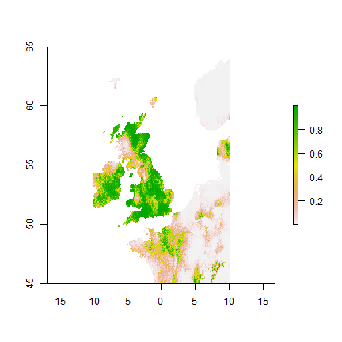

```r
# Now I'm going to run it with a different raster

library(raster)

# Get Bioclim data (using the getData function in the raster package,
# which zoon loads) ...

BioclimData <- getData('worldclim', var = 'bio', res = 5)
BioclimData <- BioclimData[[1:19]]

# ... and crop to Australia

cropped <- crop(BioclimData,
                c(109,155,-46,-7))

# Run it with my new raster

work11 <- workflow(occurrence = UKAnophelesPlumbeus,
                   covariate  = UKBioclim,
                   process    = OneHundredBackground,
                   model      = LogisticRegression,
                   output     = PredictNewRasterMap(raster = cropped))
```

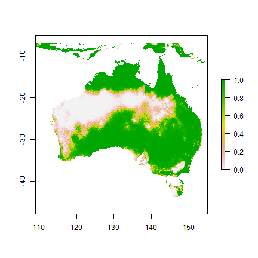

```r
# The prediction map should also be returned as a raster

class(Output(work11))
```

```
## [1] "RasterLayer"
## attr(,"package")
## [1] "raster"
```

The next stage is to turn this function into a module which is shareable. To do this we need to add metadata to our function using the `BuildModule()` function

```r
# Build our module

BuildModule(PredictNewRasterMap,
            type = 'output',
            title = 'Predict to a new raster and map',
            description = paste('This output module predicts the species',
                                'distribution in a new area given a new',
                                'raster'),
            details = paste('The results are printed as a map and a raster is',
                            'returned with the predicted values. It is important',
                            'that the new raster has the same structure as the',
                            'raster provided by the covariate module.',
                            'It must have the same covariate columns in the',
                            'same order.'),
            version = 0.1,
            author = 'Z.O. On',
            email = 'zoon@zoon-zoon.com',
            paras = list(raster = paste('A RasterBrick, RasterLayer or RasterStack in',
                                        'the same format as the raster provided',
                                        'by the covariate module. Predicted values',
                                        'will be estimated for this raster using',
                                        'the results from the model module')),
            dataType = c('presence-only', 'presence/absence', 'abundance',
                         'proportion'))
```

```
## Starting checks...
```

```
## done
```

```
## [1] "PredictNewRasterMap"
```

Once `BuildModule()` has been run there will be an `R` file in our working directory that represents our module and can be shared with others. This `R` script can be used as follows.

```r
# remove the original function from our environment

rm(list = 'PredictNewRasterMap')

# Load the module script

LoadModule('PredictNewRasterMap.R')
```

```
## [1] "PredictNewRasterMap"
```

```r
# Now I model a crop pest from Zimbabwe in its home
# range and in Australia by chaining together
# output modules

work12 <- workflow(occurrence = CWBZimbabwe,
                   covariate = Bioclim(extent = c(28, 38, -24, -16)),
                   process = NoProcess,
                   model = RandomForest,
                   output = Chain(PrintMap,
                                  PredictNewRasterMap(raster = cropped)))
```

```
## Occurrence data does not have a "crs" column, zoon will assume it is in the same projection as the covariate data
```

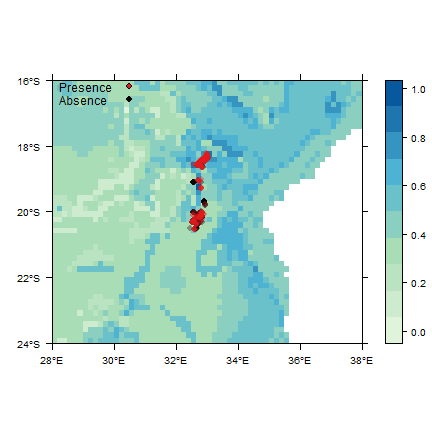

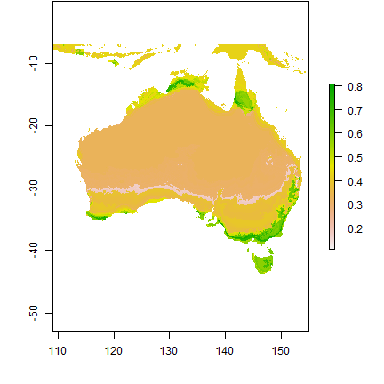

Once we’re happy with the module, we will hopefully upload it to the zoon repository. The repository is currently under development. Visit [the development pages](https://zoonproject.wordpress.com/) for more information.